# EDA OF THE ELECTRIC VEHICLE POPULATION

### BY ARAVINDAN S

BACKGROUND DETAILS AROUND THE DATA

This dataset shows the Battery Electric Vehicles (BEVs) and Plug-in Hybrid Electric Vehicles (PHEVs) that are currently registered through Washington State Department of Licensing (DOL). [State of Washington](https://catalog.data.gov/dataset/electric-vehicle-population-data) This dataset is intended for public access and use. Open Database License (ODbL)

[figure not shown]

# Preparing the data

```python
import seaborn as sns  # Seaborn for visualizations
import pandas as pd    # Pandas for data manipulation
import matplotlib.pyplot as plt  # Matplotlib for additional plot customization
```

```python
df=pd.read_csv(r"C:\Users\aravi\Downloads\Electric_Vehicle_Population_Data.csv")
```

```python
df
```

|  | VIN (1-10) | County | City | State | Postal Code | Model Year | Make | Model | Electric Vehicle Type | Clean Alternative Fuel Vehicle (CAFV) Eligibility | Electric Range | Base MSRP | Legislative District | DOL Vehicle ID | Vehicle Location | Electric Utility | 2020 Census Tract |
| --- | --- | --- | --- | --- | --- | --- | --- | --- | --- | --- | --- | --- | --- | --- | --- | --- | --- |
| 0 | JTMAB3FV3P | Kitsap | Seabeck | WA | 98380.0 | 2023 | TOYOTA | RAV4 PRIME | Plug-in Hybrid Electric Vehicle (PHEV) | Clean Alternative Fuel Vehicle Eligible | 42.0 | 0.0 | 35.0 | 240684006 | POINT (-122.8728334 47.5798304) | PUGET SOUND ENERGY INC | 5.303509e+10 |
| 1 | 1N4AZ1CP6J | Kitsap | Bremerton | WA | 98312.0 | 2018 | NISSAN | LEAF | Battery Electric Vehicle (BEV) | Clean Alternative Fuel Vehicle Eligible | 151.0 | 0.0 | 35.0 | 474183811 | POINT (-122.6961203 47.5759584) | PUGET SOUND ENERGY INC | 5.303508e+10 |
| 2 | 5YJ3E1EA4L | King | Seattle | WA | 98101.0 | 2020 | TESLA | MODEL 3 | Battery Electric Vehicle (BEV) | Clean Alternative Fuel Vehicle Eligible | 266.0 | 0.0 | 43.0 | 113120017 | POINT (-122.3340795 47.6099315) | CITY OF SEATTLE - (WA)\|CITY OF TACOMA - (WA) | 5.303301e+10 |
| 3 | 1N4AZ0CP8E | King | Seattle | WA | 98125.0 | 2014 | NISSAN | LEAF | Battery Electric Vehicle (BEV) | Clean Alternative Fuel Vehicle Eligible | 84.0 | 0.0 | 46.0 | 108188713 | POINT (-122.304356 47.715668) | CITY OF SEATTLE - (WA)\|CITY OF TACOMA - (WA) | 5.303300e+10 |
| 4 | 1G1FX6S00H | Thurston | Yelm | WA | 98597.0 | 2017 | CHEVROLET | BOLT EV | Battery Electric Vehicle (BEV) | Clean Alternative Fuel Vehicle Eligible | 238.0 | 0.0 | 20.0 | 176448940 | POINT (-122.5715761 46.9095798) | PUGET SOUND ENERGY INC | 5.306701e+10 |
| ... | ... | ... | ... | ... | ... | ... | ... | ... | ... | ... | ... | ... | ... | ... | ... | ... | ... |
| 205434 | 1N4BZ1CV2N | Chelan | Peshastin | WA | 98847.0 | 2022 | NISSAN | LEAF | Battery Electric Vehicle (BEV) | Eligibility unknown as battery range has not b... | 0.0 | 0.0 | 12.0 | 187384494 | POINT (-120.6051696 47.5510173) | PUD NO 1 OF CHELAN COUNTY | 5.300796e+10 |
| 205435 | 1FTVW1EV0P | Snohomish | Everett | WA | 98208.0 | 2023 | FORD | F-150 | Battery Electric Vehicle (BEV) | Eligibility unknown as battery range has not b... | 0.0 | 0.0 | 44.0 | 255036386 | POINT (-122.2032349 47.8956271) | PUGET SOUND ENERGY INC | 5.306104e+10 |
| 205436 | 5YJXCDE22H | Spokane | Cheney | WA | 99004.0 | 2017 | TESLA | MODEL X | Battery Electric Vehicle (BEV) | Clean Alternative Fuel Vehicle Eligible | 200.0 | 0.0 | 6.0 | 221631588 | POINT (-117.5836098 47.4951312) | BONNEVILLE POWER ADMINISTRATION\|\|AVISTA CORP\|\|... | 5.306301e+10 |
| 205437 | 5YJ3E1EA3J | King | Vashon | WA | 98070.0 | 2018 | TESLA | MODEL 3 | Battery Electric Vehicle (BEV) | Clean Alternative Fuel Vehicle Eligible | 215.0 | 0.0 | 34.0 | 336983496 | POINT (-122.466938 47.429244) | PUGET SOUND ENERGY INC\|\|CITY OF TACOMA - (WA) | 5.303303e+10 |
| 205438 | 7SAYGDEE7P | Spokane | Spokane | WA | 99208.0 | 2023 | TESLA | MODEL Y | Battery Electric Vehicle (BEV) | Eligibility unknown as battery range has not b... | 0.0 | 0.0 | 6.0 | 228335040 | POINT (-117.4268937 47.7323627) | BONNEVILLE POWER ADMINISTRATION\|\|AVISTA CORP\|\|... | 5.306301e+10 |

205439 rows × 17 columns

```python
df.columns
```

```
Index(['VIN (1-10)', 'County', 'City', 'State', 'Postal Code', 'Model Year',
       'Make', 'Model', 'Electric Vehicle Type',
       'Clean Alternative Fuel Vehicle (CAFV) Eligibility', 'Electric Range',
       'Base MSRP', 'Legislative District', 'DOL Vehicle ID',
       'Vehicle Location', 'Electric Utility', '2020 Census Tract'],
      dtype='object')
```

```python
df.isna().sum()
```

```
VIN (1-10)                                             0
County                                                 3
City                                                   3
State                                                  0
Postal Code                                            3
Model Year                                             0
Make                                                   0
Model                                                  1
Electric Vehicle Type                                  0
Clean Alternative Fuel Vehicle (CAFV) Eligibility      0
Electric Range                                         8
Base MSRP                                              8
Legislative District                                 442
DOL Vehicle ID                                         0
Vehicle Location                                       8
Electric Utility                                       3
2020 Census Tract                                      3
dtype: int64
```

```python
df=df.dropna()
```

```python
df.dtypes
```

```
VIN (1-10)                                            object
County                                                object
City                                                  object
State                                                 object
Postal Code                                          float64
Model Year                                             int64
Make                                                  object
Model                                                 object
Electric Vehicle Type                                 object
Clean Alternative Fuel Vehicle (CAFV) Eligibility     object
Electric Range                                       float64
Base MSRP                                            float64
Legislative District                                 float64
DOL Vehicle ID                                         int64
Vehicle Location                                      object
Electric Utility                                      object
2020 Census Tract                                    float64
dtype: object
```

```python
df= df.astype({'Base MSRP':int,'Postal Code':int})
```

```python
df.dtypes
```

```
VIN (1-10)                                            object
County                                                object
City                                                  object
State                                                 object
Postal Code                                            int64
Model Year                                             int64
Make                                                  object
Model                                                 object
Electric Vehicle Type                                 object
Clean Alternative Fuel Vehicle (CAFV) Eligibility     object
Electric Range                                       float64
Base MSRP                                              int64
Legislative District                                 float64
DOL Vehicle ID                                         int64
Vehicle Location                                      object
Electric Utility                                      object
2020 Census Tract                                    float64
dtype: object
```

```python
df.nunique()
```

```
VIN (1-10)                                            12127
County                                                   39
City                                                    484
State                                                     1
Postal Code                                             561
Model Year                                               22
Make                                                     42
Model                                                   152
Electric Vehicle Type                                     2
Clean Alternative Fuel Vehicle (CAFV) Eligibility         3
Electric Range                                          105
Base MSRP                                                31
Legislative District                                     49
DOL Vehicle ID                                       204983
Vehicle Location                                        561
Electric Utility                                         73
2020 Census Tract                                      1768
dtype: int64
```

```python
df['Clean Alternative Fuel Vehicle (CAFV) Eligibility'].unique()
```

```
array(['Clean Alternative Fuel Vehicle Eligible',
       'Eligibility unknown as battery range has not been researched',
       'Not eligible due to low battery range'], dtype=object)
```

```python
df['Electric Vehicle Type'].value_counts()
```

```
Electric Vehicle Type
Battery Electric Vehicle (BEV)            161218
Plug-in Hybrid Electric Vehicle (PHEV)     43765
Name: count, dtype: int64
```

```python
df['Make'].value_counts().head(15)
```

```
Make
TESLA            90098
CHEVROLET        15085
NISSAN           14513
FORD             10811
KIA               9093
BMW               8467
TOYOTA            7920
HYUNDAI           5772
RIVIAN            5667
VOLKSWAGEN        5625
JEEP              5395
VOLVO             4866
AUDI              3912
CHRYSLER          3670
MERCEDES-BENZ     1920
Name: count, dtype: int64
```

```python
df['City'].value_counts().head(15)
```

```
City
Seattle       33327
Bellevue      10234
Redmond        7341
Vancouver      7282
Bothell        6769
Kirkland       5998
Renton         5986
Sammamish      5908
Olympia        4966
Tacoma         4320
Bellingham     3401
Kent           3330
Spokane        3224
Lynnwood       3222
Tukwila        3145
Name: count, dtype: int64
```

```python
YearModel=df['Model Year'].unique()
```

```python
top5modelyear=df['Model Year'].value_counts().sort_values(ascending=False).head(5)
```

```python
modalyear=top5modelyear.index.tolist()
```

```python
modalyear
```

```
[2023, 2024, 2022, 2021, 2018]
```

```python
new_df={}
for year in modalyear:
    new_df[year]=df[df['Model Year'] == year]
```

```python
year2023=new_df[2023]
```

```python
year2024=new_df[2024]
```

```python
year2022=new_df[2022]
```

```python
year2021=new_df[2021]
```

```python
year2018=new_df[2018]
```

```python
modalyear
```

```
[2023, 2024, 2022, 2021, 2018]
```

```python
year2024.to_csv("C:\\Users\\aravi\\Downloads\\2024.csv", index=False)
```

```python
year2022.to_csv("C:\\Users\\aravi\\Downloads\\2022.csv", index=False)
```

```python
year2018.to_csv("C:\\Users\\aravi\\Downloads\\2018.csv", index=False)
```

```python
year2021.to_csv("C:\\Users\\aravi\\Downloads\\2021.csv", index=False)
```

1. Model 2021 and 2018 EDA will be done in tableau
2. Model 2024 and 2022 EDA will be done in power bi

# EV population **Analyze** & **Visualization**

```python
year2023
```

|  | VIN (1-10) | County | City | State | Postal Code | Model Year | Make | Model | Electric Vehicle Type | Clean Alternative Fuel Vehicle (CAFV) Eligibility | Electric Range | Base MSRP | Legislative District | DOL Vehicle ID | Vehicle Location | Electric Utility | 2020 Census Tract |
| --- | --- | --- | --- | --- | --- | --- | --- | --- | --- | --- | --- | --- | --- | --- | --- | --- | --- |
| 0 | JTMAB3FV3P | Kitsap | Seabeck | WA | 98380 | 2023 | TOYOTA | RAV4 PRIME | Plug-in Hybrid Electric Vehicle (PHEV) | Clean Alternative Fuel Vehicle Eligible | 42.0 | 0 | 35.0 | 240684006 | POINT (-122.8728334 47.5798304) | PUGET SOUND ENERGY INC | 5.303509e+10 |
| 7 | 7FCTGAAA1P | Snohomish | Arlington | WA | 98223 | 2023 | RIVIAN | R1T | Battery Electric Vehicle (BEV) | Eligibility unknown as battery range has not b... | 0.0 | 0 | 39.0 | 252414039 | POINT (-122.11597 48.194109) | PUGET SOUND ENERGY INC | 5.306105e+10 |
| 70 | KNDCR3L11P | Thurston | Olympia | WA | 98502 | 2023 | KIA | NIRO | Battery Electric Vehicle (BEV) | Eligibility unknown as battery range has not b... | 0.0 | 0 | 22.0 | 221481172 | POINT (-122.943445 47.059252) | PUGET SOUND ENERGY INC | 5.306701e+10 |
| 74 | 5UXTA6C08P | King | Seattle | WA | 98112 | 2023 | BMW | X5 | Plug-in Hybrid Electric Vehicle (PHEV) | Clean Alternative Fuel Vehicle Eligible | 30.0 | 0 | 43.0 | 218507348 | POINT (-122.300312 47.629782) | CITY OF SEATTLE - (WA)\|CITY OF TACOMA - (WA) | 5.303301e+10 |
| 95 | KNDC4DLC0P | Thurston | Tumwater | WA | 98512 | 2023 | KIA | EV6 | Battery Electric Vehicle (BEV) | Eligibility unknown as battery range has not b... | 0.0 | 0 | 22.0 | 240185648 | POINT (-122.957046 46.991391) | PUGET SOUND ENERGY INC | 5.306701e+10 |
| ... | ... | ... | ... | ... | ... | ... | ... | ... | ... | ... | ... | ... | ... | ... | ... | ... | ... |
| 205428 | 3FMTK2SU7P | Snohomish | Marysville | WA | 98270 | 2023 | FORD | MUSTANG MACH-E | Battery Electric Vehicle (BEV) | Eligibility unknown as battery range has not b... | 0.0 | 0 | 38.0 | 245592287 | POINT (-122.1515174 48.0650751) | PUGET SOUND ENERGY INC | 5.306105e+10 |
| 205432 | 7SAYGDEE5P | Spokane | Nine Mile Falls | WA | 99026 | 2023 | TESLA | MODEL Y | Battery Electric Vehicle (BEV) | Eligibility unknown as battery range has not b... | 0.0 | 0 | 6.0 | 259908589 | POINT (-117.6098695 47.8047804) | BONNEVILLE POWER ADMINISTRATION\|\|AVISTA CORP\|\|... | 5.306301e+10 |
| 205433 | WA1E2AFY9P | Clark | Vancouver | WA | 98664 | 2023 | AUDI | Q5 E | Plug-in Hybrid Electric Vehicle (PHEV) | Not eligible due to low battery range | 23.0 | 0 | 49.0 | 240695682 | POINT (-122.575383 45.620105) | BONNEVILLE POWER ADMINISTRATION\|\|PUD NO 1 OF C... | 5.301104e+10 |
| 205435 | 1FTVW1EV0P | Snohomish | Everett | WA | 98208 | 2023 | FORD | F-150 | Battery Electric Vehicle (BEV) | Eligibility unknown as battery range has not b... | 0.0 | 0 | 44.0 | 255036386 | POINT (-122.2032349 47.8956271) | PUGET SOUND ENERGY INC | 5.306104e+10 |
| 205438 | 7SAYGDEE7P | Spokane | Spokane | WA | 99208 | 2023 | TESLA | MODEL Y | Battery Electric Vehicle (BEV) | Eligibility unknown as battery range has not b... | 0.0 | 0 | 6.0 | 228335040 | POINT (-117.4268937 47.7323627) | BONNEVILLE POWER ADMINISTRATION\|\|AVISTA CORP\|\|... | 5.306301e+10 |

60062 rows × 17 columns

```python
year2023.shape
```

```
(60062, 17)
```

```python
year2023.columns
```

```
Index(['VIN (1-10)', 'County', 'City', 'State', 'Postal Code', 'Model Year',
       'Make', 'Model', 'Electric Vehicle Type',
       'Clean Alternative Fuel Vehicle (CAFV) Eligibility', 'Electric Range',
       'Base MSRP', 'Legislative District', 'DOL Vehicle ID',
       'Vehicle Location', 'Electric Utility', '2020 Census Tract'],
      dtype='object')
```

```python
Top3County=year2023['County'].value_counts().head(3).index.tolist()
Top3County
```

```
['King', 'Snohomish', 'Pierce']
```

```python
Top3Cities=year2023['City'].value_counts().head(3).index.tolist()
Top3Cities
```

```
['Seattle', 'Bellevue', 'Bothell']
```

```python
TopState=year2023['State'].value_counts().head().index.tolist()
TopState
```

```
['WA']
```

```python
Q={}
for County in Top3County:
    Q[County]=year2023[year2023['County'] == County]
```

```python
# Regional Variation in county
King2023=Q['King']
Snohomish2023=Q['Snohomish']
Pierce=Q['Pierce']
```

```python
C={}
for city in Top3Cities:
    C[city]=year2023[year2023['City']==city]
```

```python
#Regional Variation in Cities
Seattle2023=C['Seattle']
Bellevue2023=C['Bellevue']
Bothell2023=C['Bothell']
```

```python
year2023['Electric Vehicle Type'].unique()
```

```
array(['Plug-in Hybrid Electric Vehicle (PHEV)',
       'Battery Electric Vehicle (BEV)'], dtype=object)
```

```python
year2023[year2023['Electric Vehicle Type']=='Plug-in Hybrid Electric Vehicle (PHEV)'].shape
```

```
(7635, 17)
```

```python
year2023[year2023['Electric Vehicle Type']=='Battery Electric Vehicle (BEV)'].shape
```

```
(52427, 17)
```

```python
VehicleType=year2023['Electric Vehicle Type'].value_counts()
```

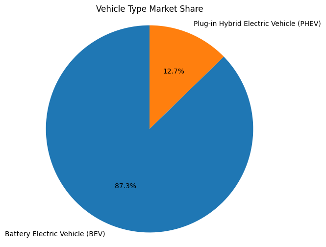

```python
# Pie chart using Matplotlib
plt.figure(figsize=(6,6))
plt.pie(VehicleType,labels=VehicleType.index, autopct='%1.1f%%', startangle=90)

# Equal aspect ratio ensures that pie is drawn as a circle.
plt.axis('equal')
plt.title('Vehicle Type Market Share')

plt.show()
```

```python
cond=year2023['Electric Vehicle Type']=='Plug-in Hybrid Electric Vehicle (PHEV)'
```

```python
hybridvehicle=year2023.loc[cond,'Make'].value_counts().head()
hybridvehicle
```

```
Make
JEEP        2163
CHRYSLER    1248
KIA         1063
TOYOTA       769
BMW          747
Name: count, dtype: int64
```

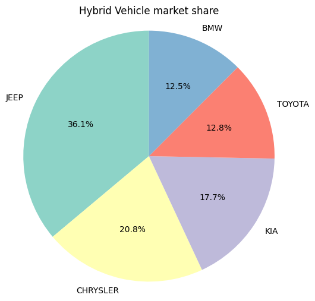

```python
# Pie chart using Matplotlib
plt.figure(figsize=(6,6))
plt.pie(hybridvehicle, labels=hybridvehicle.index, autopct='%1.1f%%', startangle=90, colors=sns.color_palette("Set3"))

# Equal aspect ratio ensures that pie is drawn as a circle.
plt.axis('equal')
plt.title('Hybrid Vehicle market share')

plt.show()
```

```python
county_countsh=year2023.loc[cond,'County'].value_counts()
```

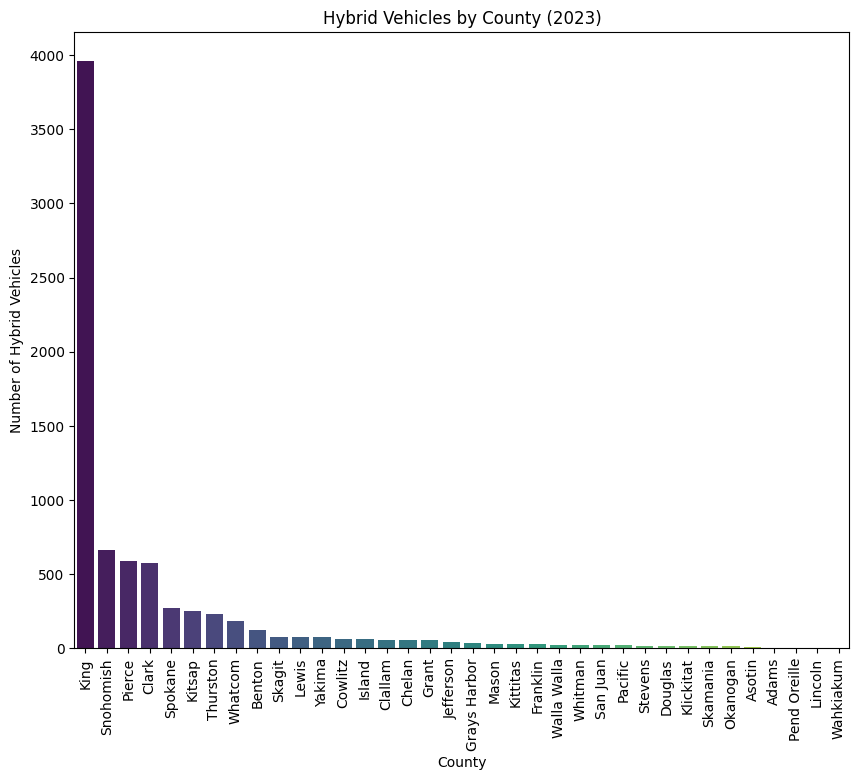

```python
plt.figure(figsize=(10, 8))
sns.barplot(x=county_countsh.index, y=county_countsh.values, palette='viridis')

# Add labels and title
plt.xlabel('County')
plt.ylabel('Number of Hybrid Vehicles')
plt.title('Hybrid Vehicles by County (2023)')
plt.xticks(rotation=90)  # Rotate x-axis labels for readability
plt.show()
```

```python
City_countsh=year2023.loc[cond,'City'].value_counts().head(45)
```

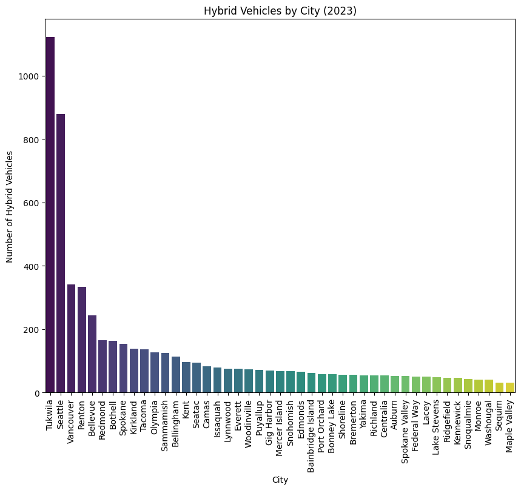

```python
plt.figure(figsize=(10, 8))
sns.barplot(x=City_countsh.index, y=City_countsh.values, palette='viridis')

# Add labels and title
plt.xlabel('City')
plt.ylabel('Number of Hybrid Vehicles')
plt.title('Hybrid Vehicles by City (2023)')
plt.xticks(rotation=90)  # Rotate x-axis labels for readability
plt.show()
```

```python
county_make_counts=year2023.loc[cond,['County','Make']].value_counts().head(45)
```

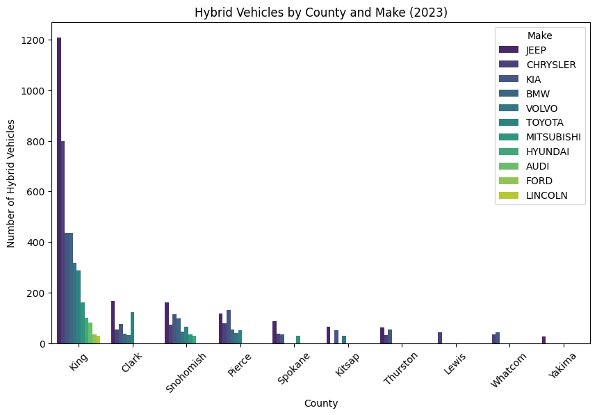

```python
# Convert the counts to a DataFrame for easier plotting
county_make_counts_df = county_make_counts.reset_index(name='Count')

# Create a bar plot
plt.figure(figsize=(10, 6))
sns.barplot(data=county_make_counts_df, x='County', y='Count', hue='Make', palette='viridis')

# Add labels and title
plt.xlabel('County')
plt.ylabel('Number of Hybrid Vehicles')
plt.title('Hybrid Vehicles by County and Make (2023)')
plt.xticks(rotation=45)  # Rotate x-axis labels for readability
plt.legend(title='Make')
plt.show()
```

```python
City_make_counts=year2023.loc[cond,['City','Make']].value_counts().head(50)
```

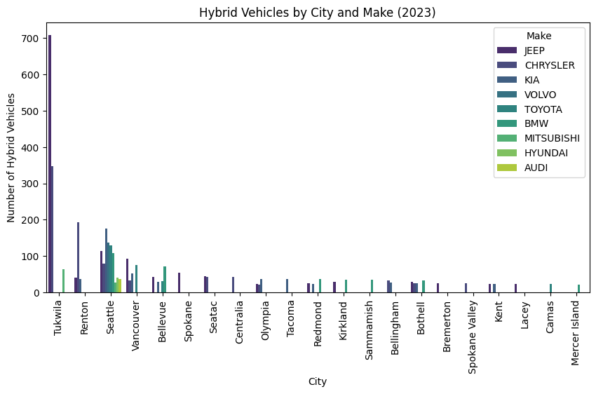

```python
# Convert the counts to a DataFrame for easier plotting
City_make_counts_df = City_make_counts.reset_index(name='Count')

# Create a bar plot
plt.figure(figsize=(10,5))
sns.barplot(data=City_make_counts_df, x='City', y='Count', hue='Make', palette='viridis')

# Add labels and title
plt.xlabel('City')
plt.ylabel('Number of Hybrid Vehicles')
plt.title('Hybrid Vehicles by City and Make (2023)')
plt.xticks(rotation=90)  # Rotate x-axis labels for readability
plt.legend(title='Make')
plt.show()
```

```python
cond2=year2023['Electric Vehicle Type']=='Battery Electric Vehicle (BEV)'
batteryvehicle=year2023.loc[cond2,'Make'].value_counts().head(5)
batteryvehicle
```

```
Make
TESLA         28145
FORD           4058
CHEVROLET      3215
RIVIAN         2888
VOLKSWAGEN     2579
Name: count, dtype: int64
```

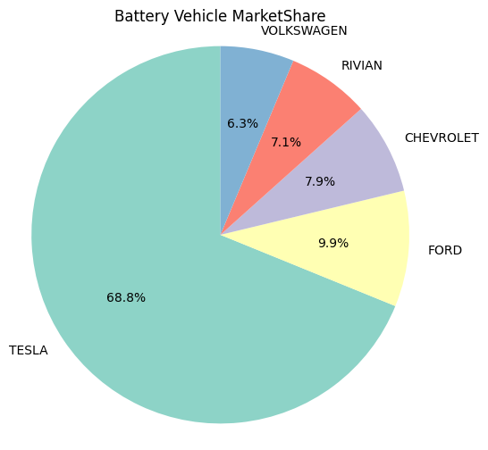

```python
# Pie chart using Matplotlib
plt.figure(figsize=(6,6))
plt.pie(batteryvehicle, labels=batteryvehicle.index, autopct='%1.1f%%', startangle=90, colors=sns.color_palette("Set3"))

# Equal aspect ratio ensures that pie is drawn as a circle.
plt.axis('equal')
plt.title('Battery Vehicle MarketShare')

plt.show()
```

```python
county_countse=year2023.loc[cond2,'County'].value_counts()
```

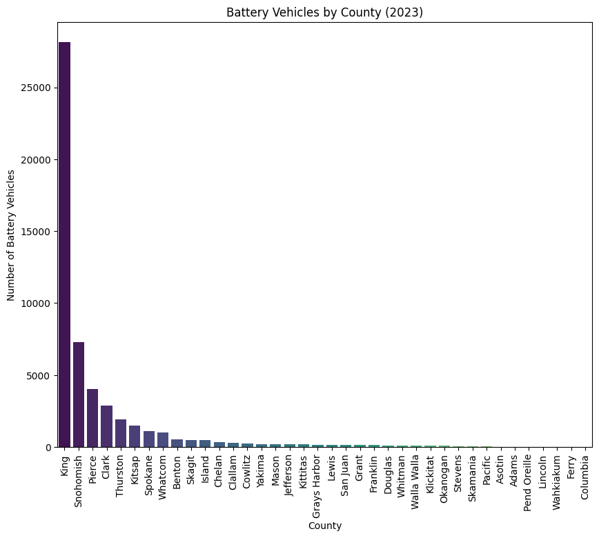

```python
plt.figure(figsize=(10, 8))
sns.barplot(x=county_countse.index, y=county_countse.values, palette='viridis')

# Add labels and title
plt.xlabel('County')
plt.ylabel('Number of Battery Vehicles')
plt.title('Battery Vehicles by County (2023)')
plt.xticks(rotation=90)  # Rotate x-axis labels for readability
plt.show()
```

```python
City_countse=year2023.loc[cond2,'City'].value_counts().head(45)
```

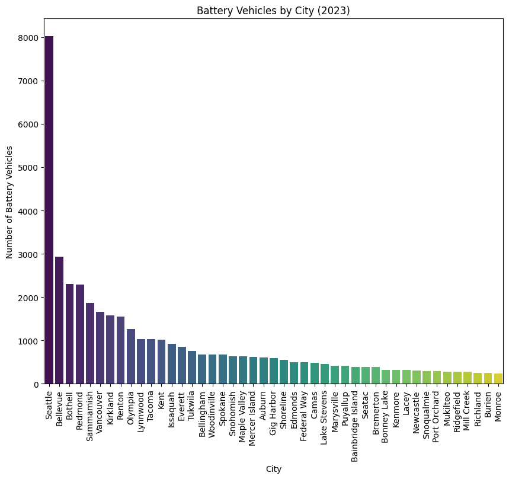

```python
plt.figure(figsize=(10, 8))
sns.barplot(x=City_countse.index, y=City_countse.values, palette='viridis')

# Add labels and title
plt.xlabel('City')
plt.ylabel('Number of Battery Vehicles')
plt.title('Battery Vehicles by City (2023)')
plt.xticks(rotation=90)  # Rotate x-axis labels for readability
plt.show()
```

```python
County_make_countse=year2023.loc[cond2,['County','Make']].value_counts().head(50)
```

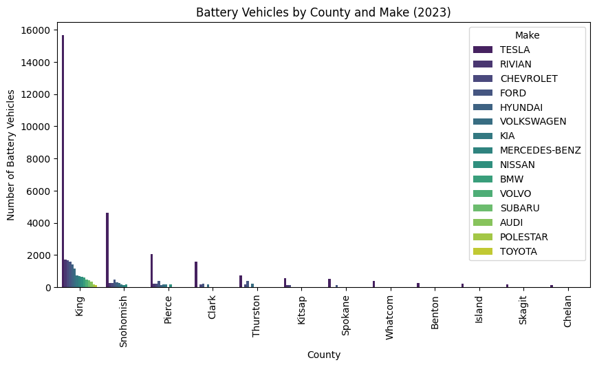

```python
# Convert the counts to a DataFrame for easier plotting
County_make_countse_df = County_make_countse.reset_index(name='Count')

# Create a bar plot
plt.figure(figsize=(10,5))
sns.barplot(data=County_make_countse_df, x='County', y='Count', hue='Make', palette='viridis')

# Add labels and title
plt.xlabel('County')
plt.ylabel('Number of Battery Vehicles')
plt.title('Battery Vehicles by County and Make (2023)')
plt.xticks(rotation=90)  # Rotate x-axis labels for readability
plt.legend(title='Make')
plt.show()
```

```python
City_make_countse=year2023.loc[cond2,['City','Make']].value_counts().head(50)
```

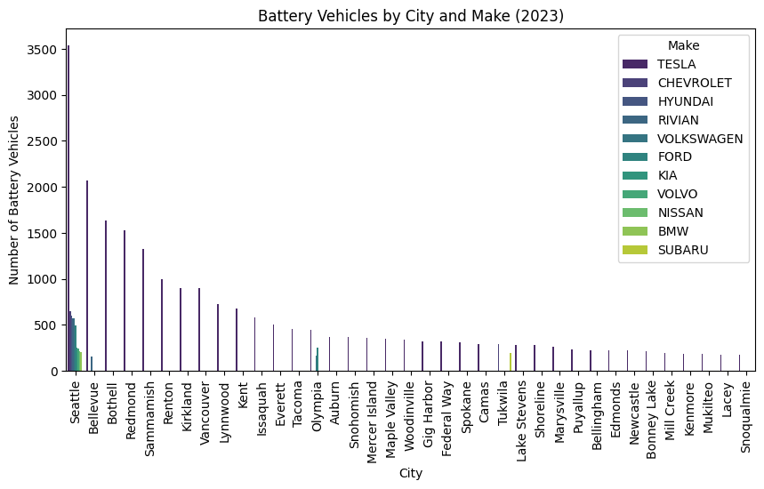

```python
# Convert the counts to a DataFrame for easier plotting
City_make_countse_df = City_make_countse.reset_index(name='Count')

# Create a bar plot
plt.figure(figsize=(10,5))
sns.barplot(data=City_make_countse_df, x='City', y='Count', hue='Make', palette='viridis')

# Add labels and title
plt.xlabel('City')
plt.ylabel('Number of Battery Vehicles')
plt.title('Battery Vehicles by City and Make (2023)')
plt.xticks(rotation=90)  # Rotate x-axis labels for readability
plt.legend(title='Make')
plt.show()
```

```python
Top5Cities=year2023['City'].value_counts().head(5).index.tolist()
Top5Cities
```

```
['Seattle', 'Bellevue', 'Bothell', 'Redmond', 'Vancouver']
```

```python
cond3 = year2023[year2023['City'].isin(Top5Cities)]
```

```python
City_Type_counts = cond3.loc[:,['City', 'Electric Vehicle Type']].value_counts()
City_Type_counts
```

```
City       Electric Vehicle Type
Seattle    Battery Electric Vehicle (BEV)            8029
Bellevue   Battery Electric Vehicle (BEV)            2940
Bothell    Battery Electric Vehicle (BEV)            2308
Redmond    Battery Electric Vehicle (BEV)            2287
Vancouver  Battery Electric Vehicle (BEV)            1662
Seattle    Plug-in Hybrid Electric Vehicle (PHEV)     879
Vancouver  Plug-in Hybrid Electric Vehicle (PHEV)     342
Bellevue   Plug-in Hybrid Electric Vehicle (PHEV)     244
Redmond    Plug-in Hybrid Electric Vehicle (PHEV)     165
Bothell    Plug-in Hybrid Electric Vehicle (PHEV)     164
Name: count, dtype: int64
```

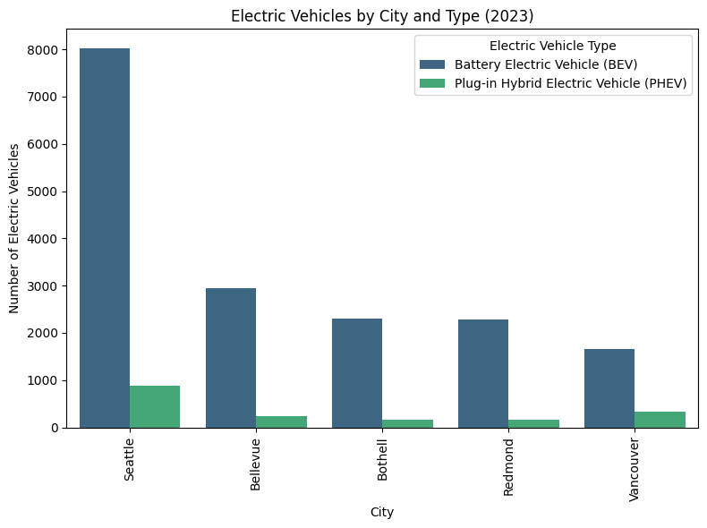

```python
City_Type_countse_df = City_Type_counts.reset_index(name='Count')
City_Type_countse_df.columns = ['City', 'Electric Vehicle Type', 'Count']
plt.figure(figsize=(8,6))
sns.barplot(data=City_Type_countse_df, x='City', y='Count', hue='Electric Vehicle Type', palette='viridis')
plt.xlabel('City')
plt.ylabel('Number of Electric Vehicles')
plt.title('Electric Vehicles by City and Type (2023)')
plt.xticks(rotation=90, fontsize=10)
plt.legend(title='Electric Vehicle Type')
plt.tight_layout()
plt.show()
```

```python
Top5County=year2023['County'].value_counts().head(5).index.tolist()
Top5County
```

```
['King', 'Snohomish', 'Pierce', 'Clark', 'Thurston']
```

```python
cond4 = year2023[year2023['County'].isin(Top5County)]
```

```python
County_Type_counts = cond4.loc[:,['County', 'Electric Vehicle Type']].value_counts()
County_Type_counts
```

```
County     Electric Vehicle Type
King       Battery Electric Vehicle (BEV)            28130
Snohomish  Battery Electric Vehicle (BEV)             7291
Pierce     Battery Electric Vehicle (BEV)             4044
King       Plug-in Hybrid Electric Vehicle (PHEV)     3959
Clark      Battery Electric Vehicle (BEV)             2881
Thurston   Battery Electric Vehicle (BEV)             1900
Snohomish  Plug-in Hybrid Electric Vehicle (PHEV)      662
Pierce     Plug-in Hybrid Electric Vehicle (PHEV)      584
Clark      Plug-in Hybrid Electric Vehicle (PHEV)      572
Thurston   Plug-in Hybrid Electric Vehicle (PHEV)      227
Name: count, dtype: int64
```

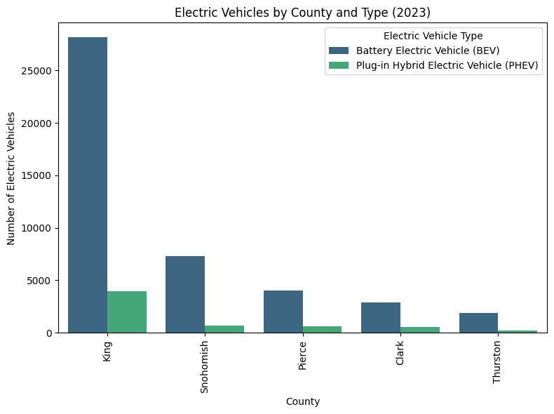

```python
County_Type_countse_df = County_Type_counts.reset_index(name='Count')
County_Type_countse_df.columns = ['County', 'Electric Vehicle Type', 'Count']
plt.figure(figsize=(8,6))
sns.barplot(data=County_Type_countse_df, x='County', y='Count', hue='Electric Vehicle Type', palette='viridis')
plt.xlabel('County')
plt.ylabel('Number of Electric Vehicles')
plt.title('Electric Vehicles by County and Type (2023)')
plt.xticks(rotation=90, fontsize=10)
plt.legend(title='Electric Vehicle Type')
plt.tight_layout()
plt.show()
```

# Reporting on finds and answer to business question

## Business questions to ask

1. **What are the top-selling counties and cities for electric vehicles?**
2. **Which vehicle type are most popular?**
3. **Are there regional variations in the popularity of different electric vehicle types (e.g., battery electric, plug-in hybrid)?**
4. **What are the market shares of different electric vehicle types (e.g., battery electric, plug-in hybrid) in different regions?**

# Answers

## 1. **What are the top-selling counties and cities for electric vehicles?**

```python
Top3County+Top3Cities
```

```
['King', 'Snohomish', 'Pierce', 'Seattle', 'Bellevue', 'Bothell']
```

## 2. **Which vehicle type are most popular?**

- Plug-in Hybrid Electric Vehicle (PHEV) AT **12.7%**
- Battery Electric Vehicle (BEV) AT **87.3%**

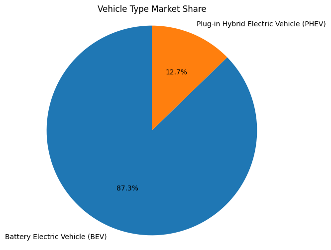

```python
plt.figure(figsize=(6,6))
plt.pie(VehicleType,labels=VehicleType.index, autopct='%1.1f%%', startangle=90)
plt.axis('equal')
plt.title('Vehicle Type Market Share')

plt.show()
```

## 3. **Are there regional variations in the popularity of different electric vehicle types (e.g., battery electric, plug-in hybrid)?**

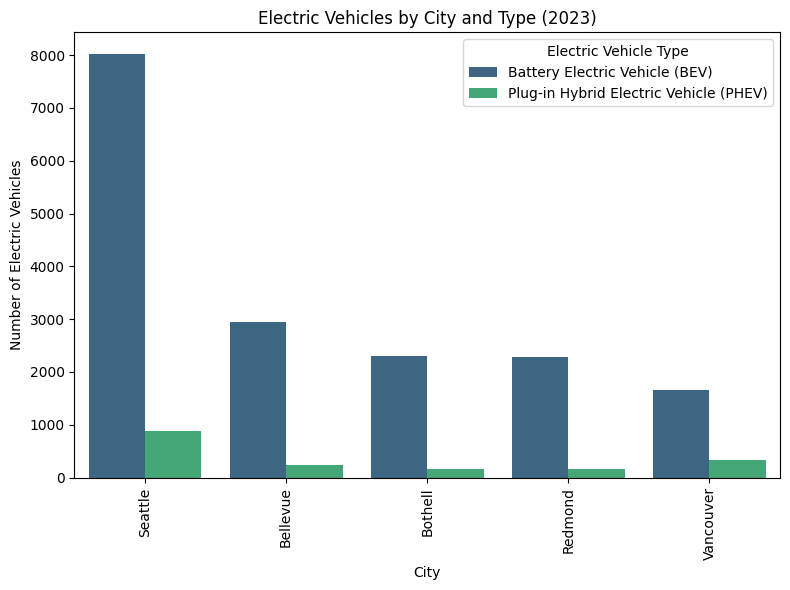

```python
City_Type_countse_df = City_Type_counts.reset_index(name='Count')
City_Type_countse_df.columns = ['City', 'Electric Vehicle Type', 'Count']
plt.figure(figsize=(8,6))
sns.barplot(data=City_Type_countse_df, x='City', y='Count', hue='Electric Vehicle Type', palette='viridis')
plt.xlabel('City')
plt.ylabel('Number of Electric Vehicles')
plt.title('Electric Vehicles by City and Type (2023)')
plt.xticks(rotation=90, fontsize=10)
plt.legend(title='Electric Vehicle Type')
plt.tight_layout()
plt.show()
```

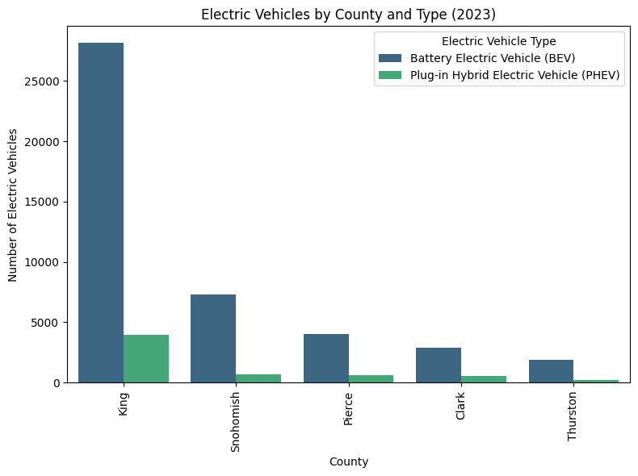

```python
County_Type_countse_df = County_Type_counts.reset_index(name='Count')
County_Type_countse_df.columns = ['County', 'Electric Vehicle Type', 'Count']
plt.figure(figsize=(8,6))
sns.barplot(data=County_Type_countse_df, x='County', y='Count', hue='Electric Vehicle Type', palette='viridis')
plt.xlabel('County')
plt.ylabel('Number of Electric Vehicles')
plt.title('Electric Vehicles by County and Type (2023)')
plt.xticks(rotation=90, fontsize=10)
plt.legend(title='Electric Vehicle Type')
plt.tight_layout()
plt.show()
```

## 4. **What are the market shares of different electric vehicle types (e.g., battery electric, plug-in hybrid) in different regions?**

### By County

```python
cond4 = year2023[year2023['County'].isin(Top5County)]
County_Type_counts = cond4.loc[:,['County', 'Electric Vehicle Type']].value_counts()
```

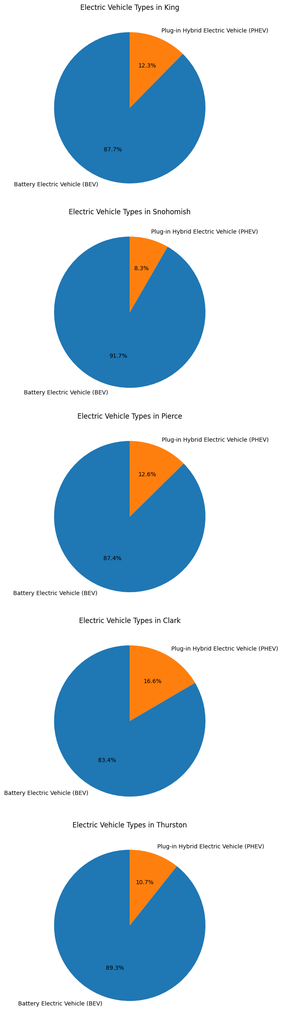

```python
county_df = County_Type_counts.reset_index(name='Count')
counties = county_df['County'].unique()
fig,axes = plt.subplots(nrows=len(counties), ncols=1, figsize=(8, 5 * len(counties)))
for ax, county in zip(axes, counties):
    county_data = county_df[county_df['County'] == county]
    ax.pie(county_data['Count'], labels=county_data['Electric Vehicle Type'], autopct='%1.1f%%', startangle=90)
    ax.set_title(f'Electric Vehicle Types in {county}')
plt.tight_layout()
plt.show()
```

### By City

```python
City_Type_counts = cond3.loc[:,['City', 'Electric Vehicle Type']].value_counts()
```

[output not shown]

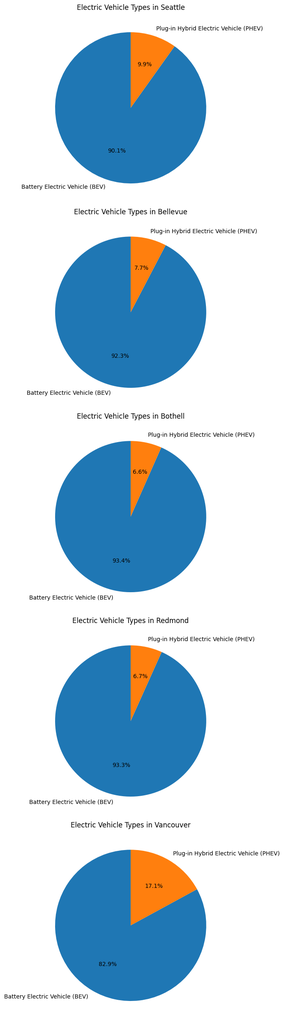

```python
city_df = City_Type_counts.reset_index(name='Count')
cities = city_df['City'].unique()
fig, axes = plt.subplots(nrows=len(cities), ncols=1, figsize=(8, 5 * len(cities)))
for ax, city in zip(axes, cities):
    city_data = city_df[city_df['City'] == city]
    ax.pie(city_data['Count'], labels=city_data['Electric Vehicle Type'], autopct='%1.1f%%', startangle=90)
    ax.set_title(f'Electric Vehicle Types in {city}')
plt.tight_layout()
plt.show()
```